# New_DYNATE_Tutorial

Jintong Zhao

2023-05-08

## Setup the DYNATE Object

For this tutorial, we will use `DYNATE` package to analyze a subset of ALS data contains 100000 rows (10138 samples, 7504 controls and 2634 cases) and total number of rare variants that all patients have are 66046.

```r
library(dplyr)
library(DYNATE)
library(data.table)
library(reshape2)
library(tibble)
# Load the ALS dataset
load("/Users/mac/Desktop/RA/ALS_Preprocessed_Data_Euro_Sample.RData")
raw = ALS_data_SNV_no_LoF_euro
```

We start by reading in the data. We only select the domain that have at least 5 SNPs records residing in them. i.e. a sample with 2 SNPs will be considered as 2 records. We first choose the domains that satisfy the criteria and then choose a subgroup of domains as the input data.

```r
set.seed(111)
raw <- raw%>%dplyr::rename(Sample.Name=ID)
#filter begin
raw <- raw%>%group_by(subRVIS.Domain.Name)%>%
  mutate(len=n())%>%
  ungroup()%>%
  filter(len>=5)%>%
  arrange(loc_adj)%>%
  mutate(snpID0=Variant.ID,snpID=rleid(loc_adj),Sample.Type=as.character(Sample.Type))%>%
  arrange(-desc(Sample.Type),Sample.Name)%>%
  mutate(Sample.ID=rleid(Sample.Name)) %>% arrange(subRVIS.Domain.Name)%>%
  mutate(domainID=rleid(subRVIS.Domain.Name))

#filter end
snp_dat1 = raw %>% select("Sample.Type","Sample.ID","snpID","domainID")
#snp_dat1 = as.data.frame(lapply(snp_dat1, sort))
snp_dat2 = snp_dat1[1:100000, ]
snp_dat2<- rename(snp_dat2, Sample.Name = Sample.ID)
snp_dat2$snpID = as.numeric(snp_dat2$snpID)
```

```r
sample_info = snp_dat2 %>% select("Sample.Name","Sample.Type")%>% unique()
```

The dimension of the `sample_info` data is $10138 \times 2$.

This data has 10138 rows and 2 columns with name `Sample.Name`, `Sample.Type`. Each row respresents an individual patient.

Here is the first 10 rows of the `sample_info` data.

```r
head(sample_info,10)
```

```
## # A tibble: 10 × 2
##    Sample.Name Sample.Type
##          <int> <chr>
##  1        1118 case
##  2        1354 case
##  3        2715 ctrl
##  4        5530 ctrl
##  5        5532 ctrl
##  6        6280 ctrl
##  7        7790 ctrl
##  8        8043 ctrl
##  9        8480 ctrl
## 10        8489 ctrl
```

`Sample.Type`: Char categorical variable. It indicates the sample in this row is from which treatment group. In this case, there are only two groups: case group or the control group.

Case group (denoted as “case”) and control group (denoted as “ctrl”) contain 2634 and 7504 samples respectively. The case group is composed of people who have the outcome of interest, while the control group is composed of people who do not have the outcome of interest.

```r
snp_info = snp_dat2 %>% select("Sample.Name","snpID","domainID")
```

The dimension of the `snp_info` data is $100000 \times 3$.

This data has 100000 rows and 3 columns with name `Sample.Name`, `snpID`,`domainID`. Each row respresents a sample specific rare variant (SNP).

Here is the first 10 rows of the `snp_info` data.

```r
head(snp_info,10)
```

```
## # A tibble: 10 × 3
##    Sample.Name  snpID domainID
##          <int>  <dbl>    <int>
##  1        1118 129786        1
##  2        1354 129786        1
##  3        2715 129786        1
##  4        5530 129786        1
##  5        5532 129786        1
##  6        6280 129786        1
##  7        7790 129787        1
##  8        8043 129784        1
##  9        8480 129786        1
## 10        8489 129785        1
```

A histogram below plots the number of samples who have the rare variant in each snp ID. For example, when the x axis Snp ID is 263301 , the y axis is 6, which means that the mutation at Snp ID = 263301 appeared in 6 samples.

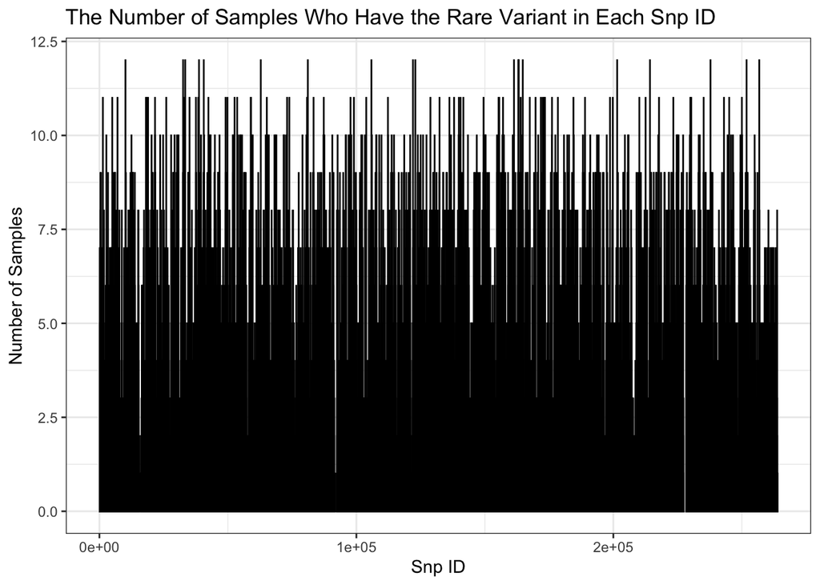

A histogram below plots the number of SNPs occurring in each domain in all samples For example, when the x axis Domain ID is 1, the y axis is 10, which means in all samples, a total of 10 variations occurred in domain 1.

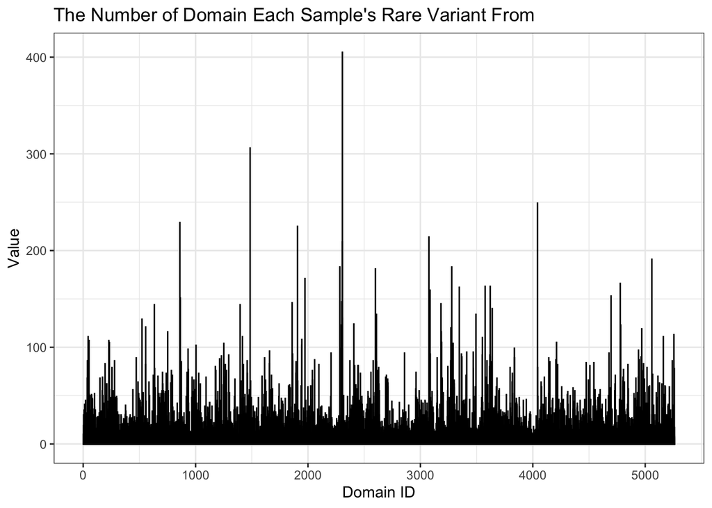

## The DYNATE Model

The `DYNATE` model and all the steps taken in the software are described in detail in our publication (Li, X., Pura, J., Allen, A., Owzar, K., Harms, M., & Xie, J. (2022)). It splits the whole-exome or genome into small regions called leaves, tests their disease associations, hierarchically aggregates these regions into larger regions, and then tests those larger regions. Here, we provide notations and include the formula and descriptions in this section as well.

After leaf P-values are calculated, we use Stouffer’s method to calculate node P-values. For node S, the P-value is
$$T_s=\bar{\Phi}\left(\sum_{i=s} \bar{\Phi}^{-1}\left(T_i\right) /
\sqrt{|S|}\right)$$

where $\bar{\Phi}(·)$ is the complementary cumulative density function of the standard Gaussian distribution.

When a node is the union of multiple leaves, we might not be able to dichotomize its null and alternative status. For example, suppose node S = {1, 2} with leaf {1} is null and leaf {2} is alternative. Then $S$ is $1 / 2$ alternative. More generally, for any node $S$, let $S_1=S \cap\{i$ : $H_i$ is alternative $\}$. Then $\theta_S=\left|S_1\right| /|S|$. We refer to $S$ as $\theta_S$-alternative or $\left(1-\theta_S\right)$-null. To address this fractional null/alternative status of nodes, we introduce a new type I error measure called node-false-discovery-rate (node-FDR),
$$\text { node-FDR }=\frac{\sum_{S \in
\mathcal{R}}\left\{1-\theta_S\right\}}{|\mathcal{R}| \vee 1}$$
Where $\mathcal{R}$ is the set of the rejected nodes.

Firstly, we use `Test_leaf` function to test the leaf-level disease associations by generating leaf p-values for case-control study. Then use `DYNATE` function to conduct hierarchical multiple testing based on the leaf p-values.

# Test_leaf Function

First, we introduce basic definition and set the tunning parameters as follows.

Leaf: We define a leaf as a gentic region where $M$ subjects carry qualifying rare variants.

Leaf size: In a leaf, if there are $M$ subjects carry qualifying rare variants. Here, $M$ denotes the leaf size. It is a much smaller number compared to $N_0$ (Number of subjects assigned in case group) and $N_1$(Number of subjects assigned in control group). When $M = 1$, only one subject carries qualifying RVs in each leaf. In practice,we recommend $M \geq 5$. A node $S$ is a union of one or more leaves. A node represents a genome region with qualifying rare variants. On higher layers ($layer \geq 2$), it aggregates the accepting nodes from the previous layer to form new nodes. For any node $S$, the set of its qualifying RVs is denoted by $V(S)$.

```r
L <- 3 # layer number
M <- 5 # leaf size
alpha <- 0.05 # desired FDR
c=left_join(snp_info,sample_info,by="Sample.Name")
c$snpID=as.numeric(c$snpID)
c=c %>% arrange(snpID,Sample.Name,domainID)
```

Second, we use `Test_Leaf` function to construct leaves and generate leaf P-values for the case-control study.

About the parameter in function `Test_leaf`.

`snp_dat`: An data frame containing patients mutation information. The structure of it is showed above.

`thresh_val`: A positive integer for leaf size.

`covars`: An optional vector about the name of covariates to be considered in the fitting process. Should be NULL (default) or a character vector.

`teststat`: The statistic used to derive p-value. Must be one of “FET” (Lancaster’s mid-P correction for the Fisher’s exact test) or “score” (efficient score statistics with saddle point approximation).

```r
p_leaf <- Test_Leaf1(snp_info = snp_info,sample_info = sample_info, thresh_val = M,teststat = "FET")
dim(p_leaf)
```

```
## [1] 66046     5
```

The dimension of the data is $66046\times 5$.

Here is the first 10 rows of the data.

```r
head(p_leaf,10)
```

```
##     L1     pvals  snpID domainID Test
##  1:  1 0.8631086 129784        1  FET
##  2:  1 0.8631086 129785        1  FET
##  3:  1 0.8631086 129786        1  FET
##  4:  1 0.8631086 129787        1  FET
##  5:  2 0.8049945 155203        2  FET
##  6:  3 0.4730875 155204        2  FET
##  7:  3 0.4730875 155205        2  FET
##  8:  3 0.4730875 155206        2  FET
##  9:  3 0.4730875 155207        2  FET
## 10:  3 0.4730875 155208        2  FET
```

`L1`: Discrete numeric variable. Leaf ID. It indicates the leaf to which the SNP corresponding to this row is assigned. The `p_leaf` data contains 15826 Leaf. 15826 < 66046 (the number of snp ID). This phenomenon illustrates that some leaves contain more than one rare variants (SNPs). The plot below gives us a more intuitive impression.

A histogram below plots the number of different rare variants(SNPs) each leaf has. For example, when the x axis Leaf ID is 1, the y axis is 4, which means we observed 4 rare variants in leaf 1 genic region.

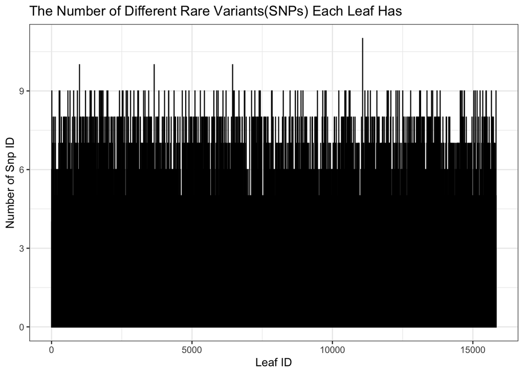

`pvals`: Continuous numeric variable. The leaf level p values.

The histogram below shows the distribution of p values.

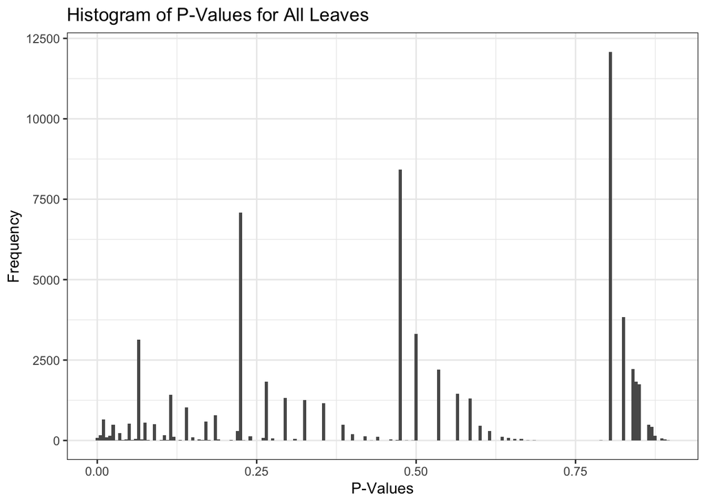

```r
p5 = ggplot(data.frame(y = p_leaf$pvals), aes(x = y)) +
  geom_histogram(binwidth = 0.005) + scale_fill_manual(name = "p-values",
                    values = "black") +
  labs(title = "Histogram of P-Values for All Leaves", x = "P-Values", y = "Frequency") +
  theme_bw()
p5
```

`snpID`: Discrete numeric variable. In total there are 66046 SNPs. The meaning is the same as `raw`$snpID`above.

`Test`: It indicates the name of the statistical test to generate the leaf level p values (FET(Fisher’s exact test) or score(efficient score statistics with saddle point approximation)). In this study, we only use `FET` statistics.

# DYNATE Function

Finally, we use the function `DYNATE` to conduct dynamic and hierarchical testing based on the leaf level p values.

About the parameter in function `DYNATE`.

`struct_map`: A data frame with both leaf information and P-value information. We can see `p_leaf` above as an example.

`L`: Maximum number of layers

`alpha`: Desired FDR (Significance level).

```r
out <- DYNATE6(struct_map=p_leaf,L=L,alpha=alpha)
dim(out)
```

```
## [1]  9 10
```

The dimension of the data is $9\times 10$.

This output data frame has 9 rows and 10 columns with name `L1`, `snpID`, `domainID`, `Test`, `pvals1`,`Layer`,`pvals-2`,`L2`,`pvals-3`,`L3`.

Each row links to a rare variant (SNPs) that belongs to a leaf with testing p-value < 1?

```r
tail(out,10)
```

```
## # A tibble: 9 × 10
##      L1 snpID domainID Test     pvals1 Layer    L2 `pvals-2`    L3 `pvals-3`
##   <int> <dbl>    <int> <chr>     <dbl> <int> <int>     <dbl> <int>     <dbl>
## 1  8607 25148     2843 FET   0.0000103     1    NA        NA    NA        NA
## 2 14656 28792     4905 FET   0.0000103     1    NA        NA    NA        NA
## 3 14656 28793     4905 FET   0.0000103     1    NA        NA    NA        NA
## 4 14656 28794     4905 FET   0.0000103     1    NA        NA    NA        NA
## 5 14656 28795     4905 FET   0.0000103     1    NA        NA    NA        NA
## 6 14656 28796     4905 FET   0.0000103     1    NA        NA    NA        NA
## 7 14656 28797     4905 FET   0.0000103     1    NA        NA    NA        NA
## 8 14656 28798     4905 FET   0.0000103     1    NA        NA    NA        NA
## 9 14656 28799     4905 FET   0.0000103     1    NA        NA    NA        NA
```

```r
p_leaf[p_leaf$L1 == 14656, ]
```

```
##       L1        pvals snpID domainID Test
## 1: 14656 1.030046e-05 28792     4905  FET
## 2: 14656 1.030046e-05 28793     4905  FET
## 3: 14656 1.030046e-05 28794     4905  FET
## 4: 14656 1.030046e-05 28795     4905  FET
## 5: 14656 1.030046e-05 28796     4905  FET
## 6: 14656 1.030046e-05 28797     4905  FET
## 7: 14656 1.030046e-05 28798     4905  FET
## 8: 14656 1.030046e-05 28799     4905  FET
```

`pvals1`: Continuous numeric variable. Same as `pvals`. The node level p values.

`Layer`: Discrete numeric variable. It indicates in which layer the SNP is detected.